# A model for preventing disease spread in large social gatherings

Based on paper, “Insights from early mathematical models of 2019-nCoV acute respiratory disease (COVID19) dynamics”  
url: https://arxiv.org/ftp/arxiv/papers/2002/2002.05296.pdf

> In this model, a simple Susceptible Exposed Infected (SEI) framework is used to propose measures to prevent epidemics during large events, e.g., during parties or concerts. The aim of the model is prevention so the Recovered compartment in SEIR framework is not considered, hence the simulation runs do not predict the whole disease outbreak in a community. The focus of the model is on disease transmission during an event that is short in duration in a population that is formed randomly.  
> $\alpha$ is the level of protection of exposed persons, the net arrival-departure rate of attendees is denoted by integer c, The $\beta$ is infection rate, derived based on the known $R_0$ and population size of the susceptibles $S_0$ as follows:

$$\beta = \frac{R_0}{\tau} + \frac{R_0}{\tau S_0}$$

> The $\tau$ is a timescale and tuning factor to adjust the parameters to the unit of time used (hours). The assumed default value for $\tau$ is 14×24=336, assuming $\tau$ is computed for a 14-day infectious period. The model also includes possible effect of super-spreading of select individuals in the $R_0$, the new expression is $R = 2 + Poisson(0.25)$. The exposure time or the number of hours an infectious person is staying in the event venue is denoted by $\delta$. The schedule of the exposure risk must be incorporated in the simulations. The expression for $\beta$ is revised as:

$$\bar\beta = (\frac{R}{\tau} + \frac{R_0}{\tau N}) \delta$$

> The $\alpha$ is multiplied by $\tau$ to adjust the timescale since the number of days for surveillance is 14 days as recommended by the $World Health Organization (2020c)$. The model is represented by:

$$\begin{aligned}
\frac{dS}{dt} & = -\bar\beta S \frac{I}{N} + \alpha E + c\\
\\
\frac{dE}{dt} & = \bar\beta S \frac{I}{N} - (1-\alpha)\tau E - \alpha\tau E = \bar\beta S \frac{I}{N} - \tau E\\
\\
\frac{dI}{dt} & = (1-\alpha) \tau E\\
\end{aligned}$$

> where $N = S + E + I_0 + 1$ (the constant 1 assures presence of at least one person in the venue of the event). The initial condition for I is assumed to be one infected.

Load the needed packages

```r
library(ggplot2)
library(jsonlite)
library(tidyverse)
require(lubridate)
library(deSolve)
```

Express the differential equations of SEI model as an R function.

```r
SEI <- function(time, state, parameters) {
  par <- as.list(c(state, parameters))
  with(par, {
    dS <- -(betaBar * S * I)/N + (alpha*E) + c
    dE <- (betaBar * S * I)/N - tau*E
    dI <- (1-alpha)*tau*E
    list(c(dS, dE, dI))
  })
}
```

Consider a Social gathering of 10000 people with initially 1 infected, with $\tau$ as default value of 14 days(336 hours).

```r
N <- 10001
init <- c(S = N - 2, E=0, I = 1)
```

Assuming initially 1 infected, if the model is left to run it’s course for 24 hours with $R_0=2, \alpha=0.3, \delta=18 hours, c=0$ then as time increases number of infecteds also increases.

```r
tau = 336
R_not = 2
R = R_not + sample(rpois(100000,lambda=0.25),1)
delta = 18
c=0
alpha=0.3
betaBar = (R/tau + R/(tau*N))*delta

Opt_par <- setNames(c(betaBar,alpha,tau), c("betaBar", "alpha", "tau"))
Opt_par
```

```
##     betaBar       alpha         tau
##   0.1071536   0.3000000 336.0000000
```

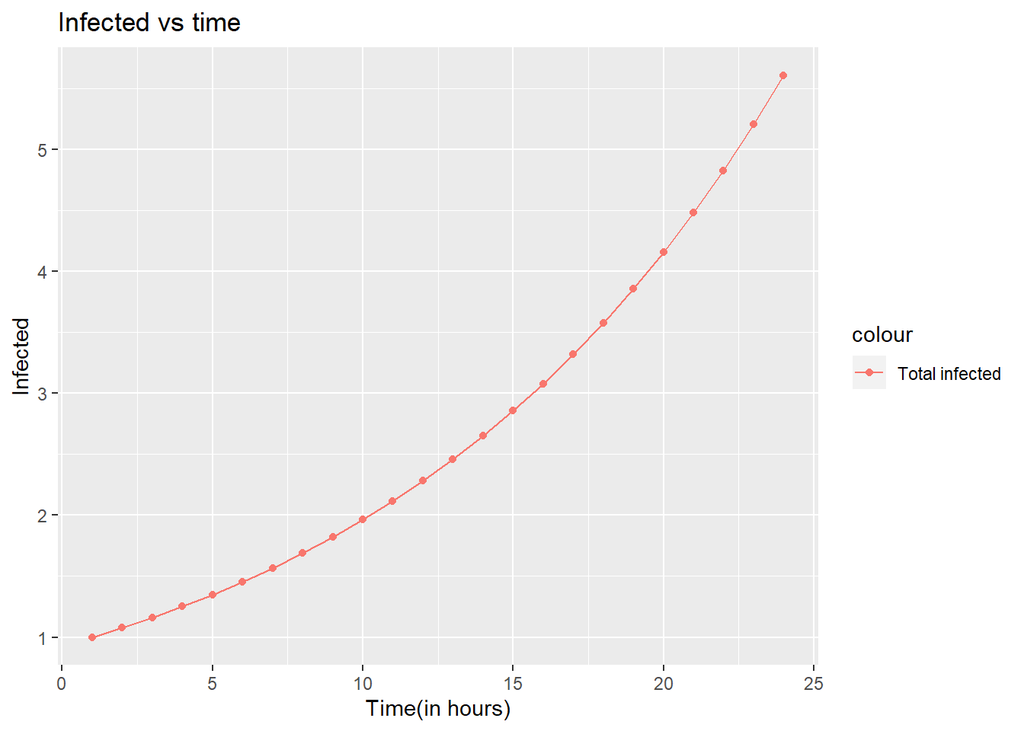

```r
t <- 1:24
fittedData <- data.frame(ode(y = init, times = t, func = SEI, parms = Opt_par))

ggplot()+labs(title="Infected vs time", x="Time(in hours)", y="Infected")+
  geom_point(fittedData, mapping=aes(x = time, y = I, group=1, color="Total infected")) +
  geom_line(fittedData, mapping=aes(x = time, y = I, group=1, color="Total infected"))
```

> The exposure time (number of hours an infectious person is staying in the event venue) is a significant factor in spreading the disease. Under the assumptions $c=0, \alpha=0$ and initial 1 infected, an infected person staying more than 10 hours could infect other people.

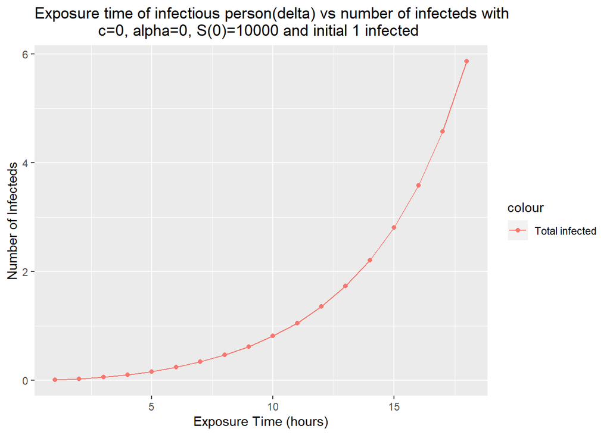

```r
deltas <- 1:18
infecteds = c()
for (i in 1:18){
  delta = deltas[i]
  c=0
  alpha=0
  betaBar = (R/tau + R/(tau*N))*delta
  Opt_par <- setNames(c(betaBar,alpha,tau), c("betaBar", "alpha", "tau"))
  t <- 1:(i+1)
  fittedData <- data.frame(ode(y = init, times = t, func = SEI, parms = Opt_par))
  infecteds <- append(infecteds, fittedData$I[i+1]-1)
}
ggplot()+labs(title="Exposure time of infectious person(delta) vs number of infecteds with
              c=0, alpha=0, S(0)=10000 and initial 1 infected", x="Exposure Time (hours)",
              y="Number of Infecteds")+
  geom_point(data.frame(infecteds,deltas), mapping=aes(x = deltas, y = infecteds, group=1, color="Total infected")) +
  geom_line(data.frame(infecteds,deltas), mapping=aes(x = deltas, y = infecteds, group=1, color="Total infected"))
```

> Assuming the exposure time $\delta$ is 18 hours, an exposed person could be protected from being infected if the level of protection is >70 percent with assumptions $c=0, \delta=18 hours$ and initial 1 infected.

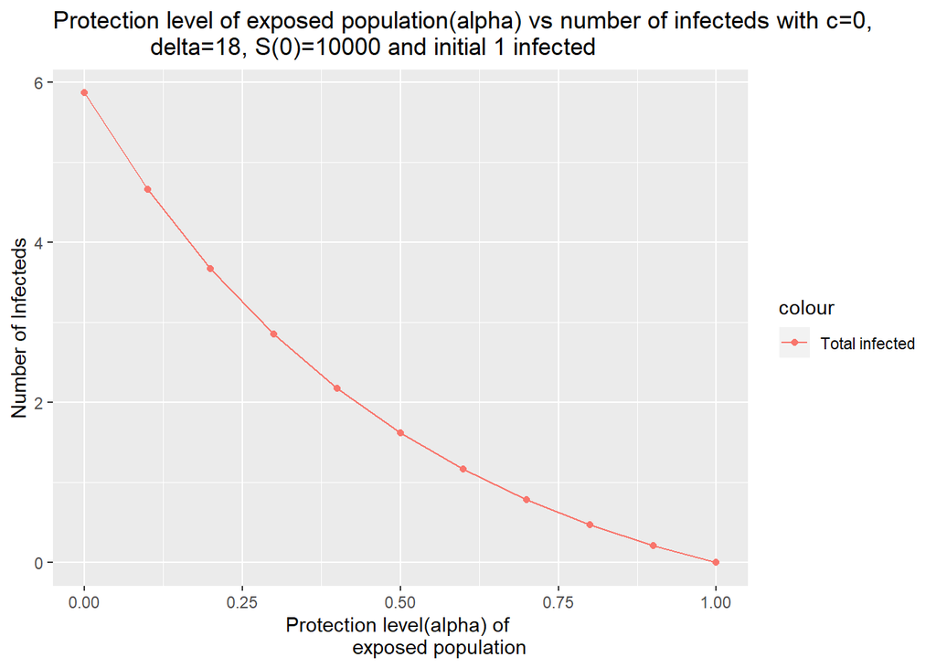

```r
N <- 10001
init <- c(S = N - 2, E=0, I = 1)
tau = 336
R_not = 2
R = R_not + sample(rpois(100000,lambda=0.25),1)
delta = 18
c=0
betaBar = (R/tau + R/(tau*N))*delta
alphas = seq(from = 0, to = 1, by = 0.1)
infecteds = c()

for (i in 1:11){
  Opt_par <- setNames(c(betaBar,alphas[i],tau), c("betaBar", "alpha", "tau"))
  t <- 1:19
  fittedData <- data.frame(ode(y = init, times = t, func = SEI, parms = Opt_par))
  infecteds <- append(infecteds, fittedData$I[19]-1)
}
ggplot()+labs(title="Protection level of exposed population(alpha) vs number of infecteds with c=0,
              delta=18, S(0)=10000 and initial 1 infected", x="Protection level(alpha) of
              exposed population", y="Number of Infecteds")+
  geom_point(data.frame(infecteds,alphas), mapping=aes(x = alphas, y = infecteds, group=1, color="Total infected")) +
  geom_line(data.frame(infecteds,alphas), mapping=aes(x = alphas, y = infecteds, group=1, color="Total infected"))
```

> The level of risk asymptotically increases when population size of the susceptible increases but the exposure time dictates if disease transmission will occur. Risk of disease transmission increases as population size of susceptibles increases. Having an exposure time $\delta$= 12 hours, new cases may occur in an event with more than 7 attendees. Assumptions $c=0, \alpha=0$.

[figure not shown]

```r
tau = 336
R_not = 2
c=0
alpha=0
delta = 12
R = R_not + sample(rpois(100000,lambda=0.25),1)
betaBar = (R/tau + R/(tau*N))*delta
infecteds = c()
susPop = c(1:30)
for (i in 1:30){
  N <- susPop[i]+1+1
  init <- c(S = N - 2, E=0, I = 1)
  betaBar = (R/tau + R/(tau*N))*delta
  Opt_par <- setNames(c(betaBar,alpha,tau), c("betaBar", "alpha", "tau"))
  t <- 1:13
  fittedData <- data.frame(ode(y = init, times = t, func = SEI, parms = Opt_par))
  infecteds <- append(infecteds, fittedData$I[13]-1)
}
ggplot()+labs(title="Susceptible population size vs number of infecteds with c=0, alpha=0, delta=12,
              S(0)=10000 and initial 1 infected", x="Susceptible population size",
              y="Number of Infecteds")+
  geom_point(data.frame(infecteds,susPop), mapping=aes(x = susPop, y = infecteds, group=1, color="Total infected")) +
  geom_line(data.frame(infecteds,susPop), mapping=aes(x = susPop, y = infecteds, group=1, color="Total infected"))
```